# The Sopranos

## Description

An American crime drama television series created by *David Chase*. The series follows *Tony Soprano* (James Gandolfini), a New Jersey Mafia boss who has panic attacks. He reluctantly begins seeing psychiatrist *Dr. Jennifer Melfi* (Lorraine Bracco), who encourages him to open up about his difficulties balancing his family life with his criminal life. Other important characters include Tony's family, Mafia colleagues, and rivals, most notably his wife *Carmela* (Edie Falco), his nephew and protégé *Christopher Moltisanti* (Michael Imperioli), and his uncle *Corrado "Junior" Soprano* (Dominic Chianese).

## Logo

[figure not shown]

## Viewership

The Sopranos viewership generally rose from modest early Season 1 numbers to its highest levels around Seasons 3 and 4. Season 4 contains the peak episode, reaching over 13 million viewers. After that, viewership gradually declined through Seasons 5 and 6A, mostly staying below earlier highs. Season 6B was lower overall, but the finale produced a major spike, showing renewed audience interest at the end of the series.

[figure not shown]

## Changes in viewership

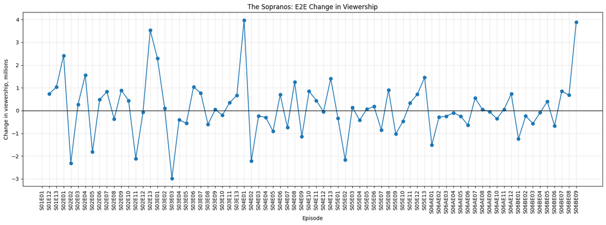

*The Sopranos* viewership was highly variable, with frequent increases and decreases between consecutive episodes. The largest positive change occurred around the transition into **S04E01**, where viewership increased by almost **4 million**. Another major increase happened at the end of the series, from **S06BE08 to S06BE09**, where viewership rose by nearly **3.9 million**.

The largest drops also occurred after major spikes. For example, after **S04E01**, viewership fell by a little over **2 million** in the next episode. Earlier in the series, there were also sharp declines, including a drop of more than **2 million** for **S02E02** and another drop of about **3 million** for **S03E03**. Later seasons show smaller episode-to-episode movements overall, especially through much of **Season 6A**, where changes mostly stayed close to zero.